# Mapping RNA on genome

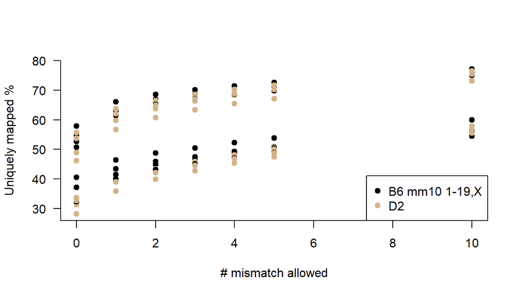

```r
# all samples in 1 graph
par(mfrow=c(1,1))
plot(x="",y="", las=1, bty="l", pch=19, xlim=c(0,10), ylim=c(floor(min(B6mm10majorchromosomes[,c("Uniq0","Uniq1","Uniq2","Uniq3","Uniq4","Uniq5","Uniq10")],D2[,c("Uniq0","Uniq1","Uniq2","Uniq3","Uniq4","Uniq5","Uniq10")])),ceiling(max(B6mm10majorchromosomes[,c("Uniq0","Uniq1","Uniq2","Uniq3","Uniq4","Uniq5","Uniq10")],D2[,c("Uniq0","Uniq1","Uniq2","Uniq3","Uniq4","Uniq5","Uniq10")]))), xlab="# mismatch allowed", ylab="Uniquely mapped %")
for(mysample in rownames(B6mm10majorchromosomes)){
  # on B6 mm10 reference
  points(c(0:5,10),B6mm10majorchromosomes[mysample,c("Uniq0","Uniq1","Uniq2","Uniq3","Uniq4","Uniq5","Uniq10")], pch=19)
  points(c(0:5,10),D2[mysample,c("Uniq0","Uniq1","Uniq2","Uniq3","Uniq4","Uniq5","Uniq10")], las=1, bty="l", pch=19, col="tan")
  legend("bottomright", legend=c("B6 mm10 1-19,X", "D2"), pch=19, col=c("black", "tan"), cex=1)
}
```

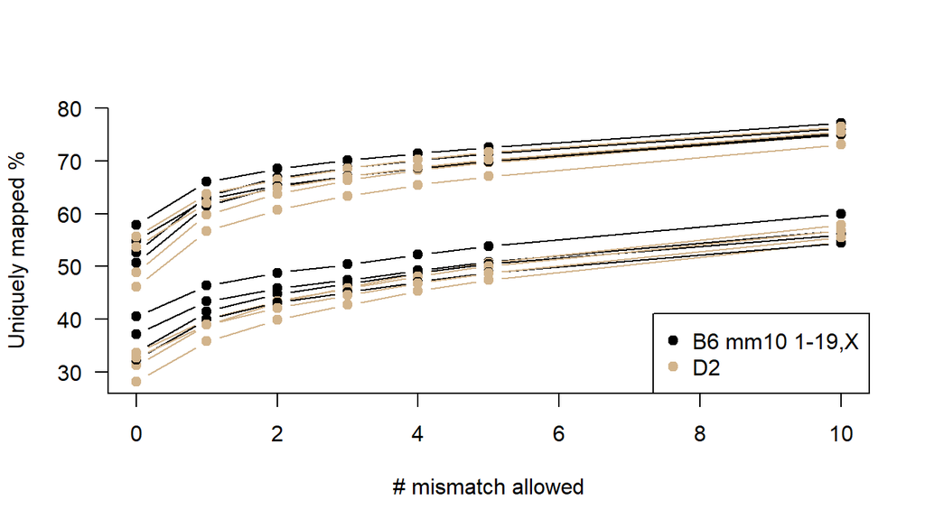

```r
# all samples in 1 graph
par(mfrow=c(1,1))
plot(x="",y="", las=1, bty="l", pch=19, xlim=c(0,10), ylim=c(floor(min(B6mm10majorchromosomes[,c("Uniq0","Uniq1","Uniq2","Uniq3","Uniq4","Uniq5","Uniq10")],D2[,c("Uniq0","Uniq1","Uniq2","Uniq3","Uniq4","Uniq5","Uniq10")])),ceiling(max(B6mm10majorchromosomes[,c("Uniq0","Uniq1","Uniq2","Uniq3","Uniq4","Uniq5","Uniq10")],D2[,c("Uniq0","Uniq1","Uniq2","Uniq3","Uniq4","Uniq5","Uniq10")]))), xlab="# mismatch allowed", ylab="Uniquely mapped %")
for(mysample in rownames(B6mm10majorchromosomes)){
  # on B6 mm10 reference
  points(c(0:5,10),B6mm10majorchromosomes[mysample,c("Uniq0","Uniq1","Uniq2","Uniq3","Uniq4","Uniq5","Uniq10")], type="b", pch=19)
  points(c(0:5,10),D2[mysample,c("Uniq0","Uniq1","Uniq2","Uniq3","Uniq4","Uniq5","Uniq10")], las=1, bty="l", type="b", pch=19, col="tan")
  legend("bottomright", legend=c("B6 mm10 1-19,X", "D2"), pch=19, col=c("black", "tan"), cex=1)
}
```

```r
# calculate diff reference-specific
mean(B6mm10majorchromosomes[CB6samples,"Uniq0"]-D2[CB6samples,"Uniq0"])
```

```
## [1] 8.85
```

```r
mean(B6mm10majorchromosomes[LB6samples,"Uniq0"]-D2[LB6samples,"Uniq0"])
```

```
## [1] 9.105
```

```r
mean(D2[CD2samples,"Uniq0"]-B6mm10majorchromosomes[CD2samples,"Uniq0"])
```

```
## [1] 3
```

```r
mean(D2[LD2samples,"Uniq0"]-B6mm10majorchromosomes[LD2samples,"Uniq0"])
```

```
## [1] 0.115
```

# Discussion

The use of more restrictive parameters and mapping on the genome instead of transcriptome seems to show:

- Still difference in mappability for the 2 tissues. Still fewer reads map from liver than from cortex.
- Some specificity of sample to its reference (B6 samples map better on B6 reference) instead of all samples map higher on D2. F1 samples map better on B6.
- This specificity seems to decrease by increasing the number of mismatch allowed.

These are due to:

- map on genome vs transcriptome?
- constraints (no indels, no splicing, no soft-clip, no mismatch)?

Various info:

- Mouse lines heterogeneozity: in the genotypes (mm9) merged, B6 shows 93% of “B” (0% of “D”, 7% of “H”, <1% of “U”), D2 shows 81% of “D” (0% of “B”, 19% of “H”, <1% of “U”). (H=heterogenous, B=homozygote B6, D=homozygote D2, U=Unknown). In the genotypes (mm9) from GeneNetwork there is no heterogenous loci for parental strains.
- Using “free” (STAR default) parameters, 77% of uniquely mapped reads on genome compared to 75.78% (unfiltered) on transcriptome (first replicate B6 NSD liver on D2 reference).
- Using restrictive parameters, 46.16% of uniquely mapped reads on genome compared to 60.02% (introns allowed) on transcriptome (first replicate B6 NSD cortex on D2 reference).

Ideas to go further:

- Be less restrictive on introns, indels, and soft-clipping? (aka just restrict mismatches)
- Check in other tissues (BXD samples from Bernard Thorens group used by Maxime for variant calling)?